# Part II - Ford GoBike System Data

## by Remi Dongmo

## Investigation Overview

In this investigation, I wanted to look at the characteristics of bike sharing data that could be used to determine if a user is subscriber or not. The main support features used were duration, time of day, day of week and age.

## Dataset Overview

The data consisted of 183,412 records of trip information charactarized by 16 features. Some important attributes included duration in second, gps coordinates, gender, start/end dates and birth date, . We converted durations to minute unit, we engineered distance covered from gps coordinates, we dropped records with outlier data and we did some data type conversions. At the end we got an appropriate bank of information to work with.

## Distribution of time of the day acording to both user types

The user type has no influence on the hourly traffic. For both customers and subscribers, most of the trips are carried out during the morning and at the end of the day. We could be tempted to deduce that many users use the bicycles to get to their 9-5 jobs or schools.

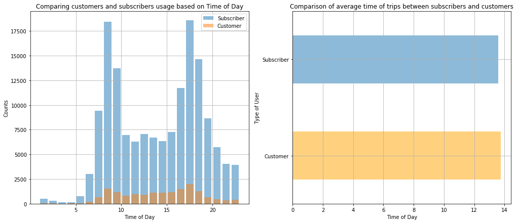

## Distribution of trip duration according to both user types

The trip duration has a quite noticeable dependence on the user type. Subscribed users ride less than half the time customers do. While customers complete their trips in **21 minutes** on average, subscribers only need **10 minutes** usually. This could be explained by the fact that paying a ride at a time and at a higher price encourages customers to enjoy their trip more longer. According to [this](https://divvybikes.com/pricing) bike sharing company pricing, single rides of 30 minutes cost **$1** while subscribers can have unlimited 45 minutes rides for only **$10/month**

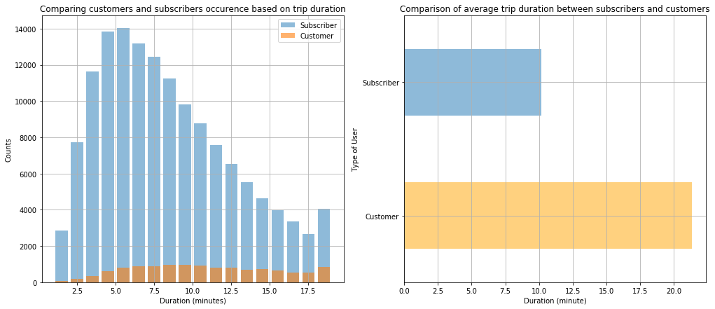

## Duration and traffic of trips per week day according to both user types

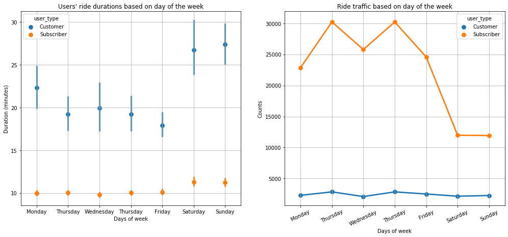

## Age by gender according to wether or not rides are all trip bike shares

Whatever their gender, users are less open to do all trip bike shares as they get older. However, this is surprisingly more visible for males. Obviously, doing all trip bike shares is very dependent on both the gender and the age of users.

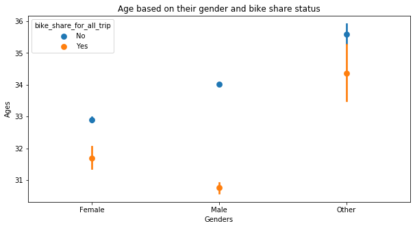